# Data Analysis

### Load libraries

```r
library("quanteda", quietly = TRUE, warn.conflicts = FALSE, verbose = FALSE)
library(tidyverse, quietly = TRUE, warn.conflicts = FALSE, verbose = FALSE)
library(stringr)
library(quanteda.textstats)
library(quanteda.dictionaries)
library(quanteda.sentiment)
library(quanteda.textplots)
library(topicmodels)
```

We now turn to the analysis of the specific characteristics of arguments that make them more persuasive. Using the techniques learned in the class, we will try to determine what is different about comments that receive a delta compared to those that do not.

### 1. What linguistic features make comments more convincing?

- Are comments that receive a delta longer than comments do not?
- Do comments that receive a delta contain more punctuation than those that do not?
- Does the text in comments that receive a delta have higher levels of complexity in terms of lexical diversity and readability scores?
- Are there other linguistic features that vary depending on whether a given comment is likely to be persuasive or not?

### Load data

```r
# Rename the data
r <- read.csv("cmv-comments.csv", stringsAsFactors = FALSE)
```

### Prepare data

```r
# Create a corpus
comments_corpus <- corpus(r$comment)
# Tokenize the corpus
comments_tokens <- tokens(comments_corpus)
# Convert tokenized corpus into a dfm
comments_dfm <- tokens(comments_tokens)
# Create a df with the length of each comment
comments_df <- data.frame(doc_id = docnames(comments_corpus),
                     comment_length = sapply(comments_tokens, function(x) sum(nchar(x))))
# Add the delta variable to the df
comments_df <- cbind(comments_df, delta = r$delta)
```

**Length of Comments**

```r
# Calculate summary statistics by delta value
length_by_delta <- comments_df %>%
  group_by(delta) %>%
  summarize(min = min(comment_length),
            max = max(comment_length),
            median = median(comment_length),
            mean = mean(comment_length),
            q25 = quantile(comment_length, 0.25),
            q75 = quantile(comment_length, 0.75),
            sd = sd(comment_length))

# Print the results
round(length_by_delta,1)
```

```
## # A tibble: 2 × 8
##   delta   min   max median  mean   q25   q75    sd
##   <dbl> <dbl> <dbl>  <dbl> <dbl> <dbl> <dbl> <dbl>
## 1     0    35  5649   334.  512.  156.  618.  597.
## 2     1    29  6072   614   873   295  1096   877.
```

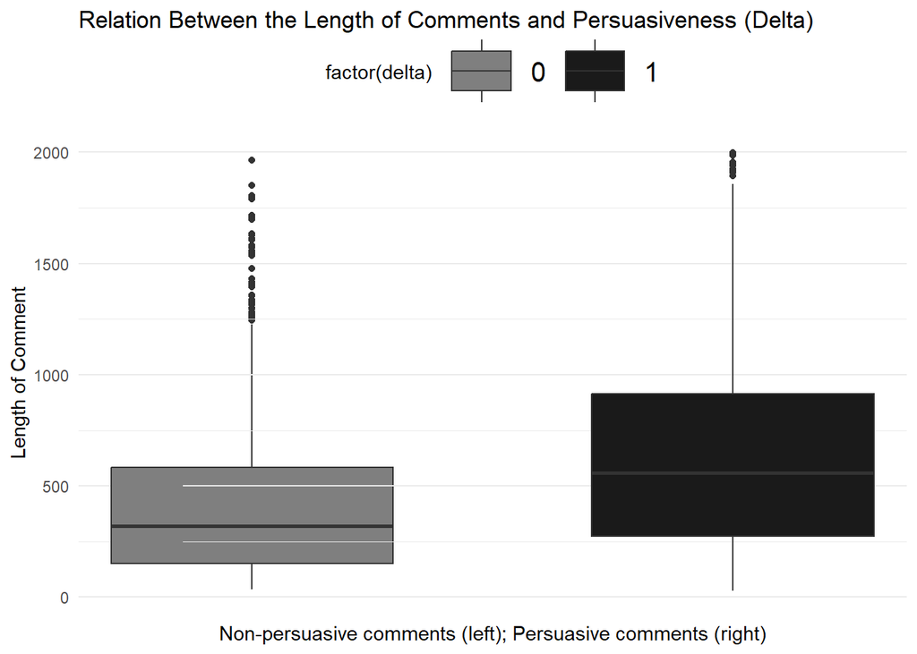

```r
# Create a boxplot of comment lengths by delta value
ggplot(comments_df, aes(x = delta, y = comment_length, fill = factor(delta))) +
  geom_boxplot() +
  scale_fill_manual(values = c("gray50", "gray10")) +
  facet_wrap(~ delta, ncol = 2) +
  ylim(20, 2000) +  # set y-axis limits to end at 2,000
  labs(title = "Relation Between the Length of Comments and Persuasiveness (Delta)",
       x = "Non-persuasive comments (left); Persuasive comments (right)",
       y = "Length of Comment") +
  theme_minimal() +
  theme(panel.spacing = unit(-12, "cm"),
        legend.position = "top",
        legend.margin = margin(-0.2, 0, 0, 0, "cm"),
        axis.text.x = element_blank(),
        axis.line.x.top = element_blank(),
        panel.grid.major.x = element_blank(),
        panel.grid.minor.x = element_blank(),
        strip.text.x = element_blank(),
        legend.text = element_text(size = 15),
        legend.key.size = unit(3, "lines"))
```

**Punctuation in comments**

```r
# Create a df with the number of punctuation marks in each comment
comments_punct_df <- r %>%
  # Use basic regex to count punctuations
  mutate(punct_count = str_count(comment, "[[:punct:]]")) %>%
  select(punct_count, delta)
# Calculate Calculate summary statistics by delta value
punct_by_delta <- comments_punct_df %>%
  group_by(delta) %>%
  summarize(min = min(punct_count),
            max = max(punct_count),
            median = median(punct_count),
            mean = mean(punct_count),
            q25 = quantile(punct_count, 0.25),
            q75 = quantile(punct_count, 0.75),
            sd = sd(punct_count))
# Print the results
round(punct_by_delta, 1)
```

```
## # A tibble: 2 × 8
##   delta   min   max median  mean   q25   q75    sd
##   <dbl> <dbl> <dbl>  <dbl> <dbl> <dbl> <dbl> <dbl>
## 1     0     0   310     11  18.8     5    22  25
## 2     1     1   375     21  34.8    10    42  42.1
```

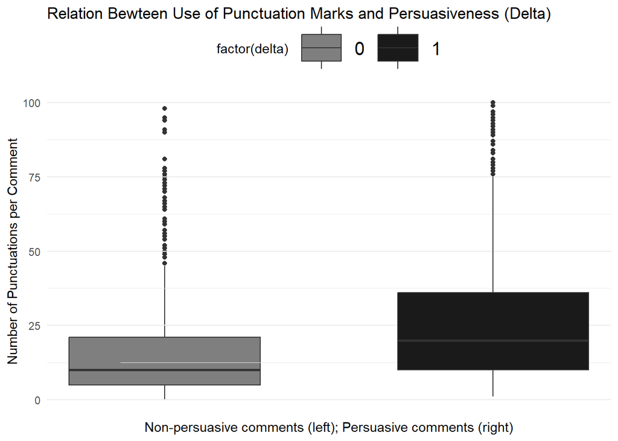

```r
# Create a boxplot of number of punctuations by delta value
ggplot(comments_punct_df, aes(x = delta, y = punct_count, fill = factor(delta))) +
  geom_boxplot() +
  scale_fill_manual(values = c("gray50", "gray10")) +
  facet_wrap(~ delta, ncol = 2) +
  ylim(0, 100) +  # set y-axis limits to end at 100
  labs(title = "Relation Bewteen Use of Punctuation Marks and Persuasiveness (Delta)",
       x = "Non-persuasive comments (left); Persuasive comments (right)",
       y = "Number of Punctuations per Comment") +
  theme_minimal() +
  theme(panel.spacing = unit(-12, "cm"),
        legend.position = "top",
        legend.margin = margin(-0.2, 0, 0, 0, "cm"),
        axis.text.x = element_blank(),
        axis.line.x.top = element_blank(),
        panel.grid.major.x = element_blank(),
        panel.grid.minor.x = element_blank(),
        strip.text.x = element_blank(),
        legend.text = element_text(size = 15),
        legend.key.size = unit(3, "lines"))
```

**Do comments that receive a delta contain more punctuation than those that do not?**

**Lexical diversity**

```r
# Create a clean tokenized corpus
comments_clean_tokens <- tokens(comments_corpus,
                                remove_punct = T,
                                remove_symbols = T,
                                remove_numbers = T,
                                remove_url = T)
# Remove stopwords for a better analysis of lexical diversity (as in lab-session 1)
comments_clean_tokens <- tokens_remove(comments_clean_tokens, stopwords("english"))
# Create a clean dfm from the clean tokenized corpus, nowwithout stopwords as well
comments_clean_dfm <- dfm(comments_clean_tokens)
# Extract the lexical diversity according to all measures available in textstat_lexdiv()
tstat_lexdiv <- textstat_lexdiv(comments_clean_dfm, measure=c("all"))
# Add the delta variable to the df and remove Na values
tstat_lexdiv <- cbind((as.data.frame(tstat_lexdiv)), delta = r$delta) %>%
  drop_na()
# Calculate mean of different measures lexical diversity grouped by delta value
lexdiv_by_delta <- tstat_lexdiv %>%
  group_by(delta) %>%
  summarize(# mean stats for different measures for lexical diversity
            mean_TTR = mean(TTR),
            mean_C = mean(C),
            mean_R = mean(R),
            mean_CTTR = mean(CTTR),
            mean_K = mean(K),
            mean_I = mean(I),
            mean_D = mean(D),
            mean_Vm = mean(Vm),
            mean_Maas = mean(Maas))
# Print the results
round(lexdiv_by_delta, 2)
```

```
## # A tibble: 2 × 10
##   delta mean_TTR mean_C mean_R mean_CTTR mean_K mean_I mean_D mean_Vm mean_Maas
##   <dbl>    <dbl>  <dbl>  <dbl>     <dbl>  <dbl>  <dbl>  <dbl>   <dbl>     <dbl>
## 1     0     0.87   0.96   5.52       3.9   72.4   74.4   0.01    0.05      0.13
## 2     1     0.82   0.95   6.78       4.8   79.1   80.9   0.01    0.06      0.15
```

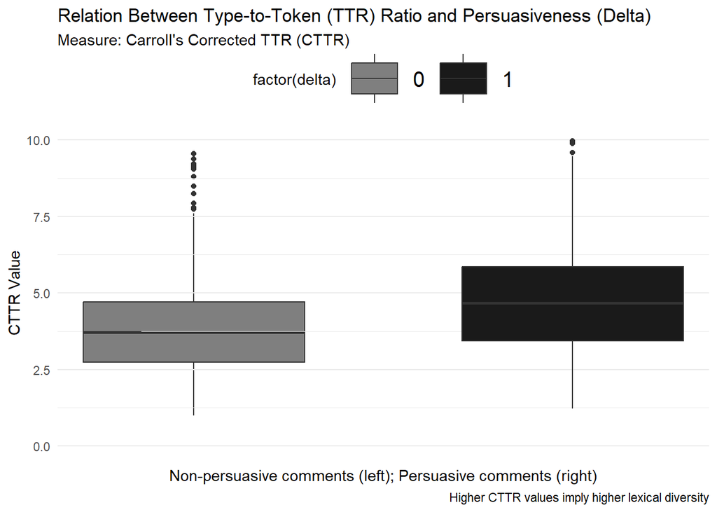

```r
# Create a boxplot of lexical diversity by delta value
ggplot(tstat_lexdiv, aes(x = delta, y = CTTR, fill = factor(delta))) +
  geom_boxplot() +
  scale_fill_manual(values = c("gray50", "gray10")) +
  facet_wrap(~ delta, ncol = 2) +
  ylim(0, 10) +
  labs(title = "Relation Between Type-to-Token (TTR) Ratio and Persuasiveness (Delta)",
       subtitle = "Measure: Carroll's Corrected TTR (CTTR)",
       caption = "Higher CTTR values imply higher lexical diversity",
       x = "Non-persuasive comments (left); Persuasive comments (right)",
       y = "CTTR Value") +
  theme_minimal() +
  theme(panel.spacing = unit(-12, "cm"),
        legend.position = "top",
        legend.margin = margin(-0.2, 0, 0, 0, "cm"),
        axis.text.x = element_blank(),
        axis.line.x.top = element_blank(),
        panel.grid.major.x = element_blank(),
        panel.grid.minor.x = element_blank(),
        strip.text.x = element_blank(),
        legend.text = element_text(size = 15),
        legend.key.size = unit(3, "lines"))
```

**Text Readability**

```r
# Extract the text readability according to some of the measures available in textstat_readability()
tstat_readability <- textstat_readability(comments_corpus, measure = c("Flesch",
                                                  "Flesch.Kincaid",
                                                  "Coleman.Liau.grade",
                                                  "ARI",
                                                  "SMOG"))
# Add the delta variable to the df and remove Na values
tstat_readability <- cbind((as.data.frame(tstat_readability)), delta = r$delta) %>%
  drop_na() %>%
  mutate(grade = (Flesch.Kincaid + Coleman.Liau.grade + ARI)/3)
# Calculate mean of different measures text readability grouped by delta value
readability_by_delta <- tstat_readability %>%
  group_by(delta) %>%
  summarize(# mean stats for different measures for text readability
            mean_Flesch = mean(Flesch),
            mean_Flesch.Kincaid = mean(Flesch.Kincaid),
            mean_Coleman.Liau.grade = mean(Coleman.Liau.grade),
            mean_ARI = mean(ARI),
            mean_grade = mean(grade),
            mean_SMOG = mean(SMOG))
# Print the results
round(readability_by_delta, 2)
```

```
## # A tibble: 2 × 7
##   delta mean_Flesch mean_Flesch.Kincaid mean_Coleman.L…¹ mean_…² mean_…³ mean_…⁴
##   <dbl>       <dbl>               <dbl>            <dbl>   <dbl>   <dbl>   <dbl>
## 1     0        59.0                9.79             9.39    9.86    9.68    11.4
## 2     1        54.0               10.9             10.3    11.3    10.8     12.2
## # … with abbreviated variable names ¹mean_Coleman.Liau.grade, ²mean_ARI,
## #   ³mean_grade, ⁴mean_SMOG
```

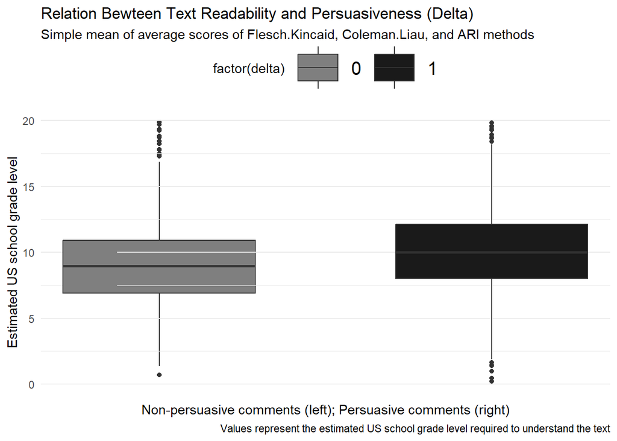

```r
# Create a boxplot of text readability by delta value
ggplot(tstat_readability, aes(x = delta, y = grade, fill = factor(delta))) +
  geom_boxplot() +
  scale_fill_manual(values = c("gray50", "gray10")) +
  facet_wrap(~ delta, ncol = 2) +
  ylim(0, 20) +
  labs(title = "Relation Bewteen Text Readability and Persuasiveness (Delta)",
       subtitle = "Simple mean of average scores of Flesch.Kincaid, Coleman.Liau, and ARI methods",
       caption = "Values represent the estimated US school grade level required to understand the text",
       x = "Non-persuasive comments (left); Persuasive comments (right)",
       y = "Estimated US school grade level") +
  theme_minimal() +
  theme(panel.spacing = unit(-12, "cm"),
        legend.position = "top",
        legend.margin = margin(-0.2, 0, 0, 0, "cm"),
        axis.text.x = element_blank(),
        axis.line.x.top = element_blank(),
        panel.grid.major.x = element_blank(),
        panel.grid.minor.x = element_blank(),
        strip.text.x = element_blank(),
        legend.text = element_text(size = 15),
        legend.key.size = unit(3, "lines"))
```

**Does the text in comments that receive a delta have higher levels of complexity (lexical diversity and readability scores)?**

1. **Lexical diversity:***The lexical diversity of persuasive comments is higher for some but not all measures that calculate lexical diversity. For this analysis we focused on the corpus that has already been cleaned as it contains no punctuation marks, symbols, numbers and common non-relevant English words (“stopwords”). The mean of the most basic measure, Type-to-Token ratio or “TTR” even suggests that the lexical diversity is larger for non-persuasive comments. In contrast, the mean of other measures such as R, CTTR, K, I, Vm, and Maas suggest the opposite. The plot focuses on the CTTR value, known as the Carroll’s Corrected TTR. This measure is good for this data, as it corrects for the length of the text by taking the double of the squared root of the number of tokens (words). Previously, it was shown that the persuasive comments are lengthier. Thus, “CTTR” as well as “I” should compare the lexical diversity better than the common TTR. Still, the mixed results in terms of lexical diversity do not show a highly significant difference between the two types of comments, even though there is some ground to say that persuasive comments are more lexically diverse. The means of different measures are printed above, as well as the boxplot using CTTR. The upper limit of the y-values of the plot is limited at 10 for a better visualization.*
2. **Readability:***The results in terms of text readability are similar to the lexical diversity comparison. The mean value of the Flesch measure suggests that the readability is slightly higher for non-persuasive comments. However, other measures suggest the opposite. For example, there are at least three measures (Flesch.Kinkaid, Coleman.Liau, and ARI) whose output is expressed in terms of the US school grade required to understand the text that show that persuasive comments require higher readability levels. The SMOG, that measures the estimated years of schooling to understand the text, also point at higher levels of readability for persuasive comments. The mean values of all the measures before mentdioned are printed in the table above, as well as a boxplot in terms of the simple mean of the three measures that are expressed in terms of the US school grade required to understand the text. Again, even though there is some basis to say that the readability of persuasive comments is higher, the difference to non-persuasive comments is not very significant. The upper limit of the y-values of the plot is limited at 20 for a better visualization.*

**Question Marks**

```r
# Apply question_mark_counts function to r$comment column
r_question_marks <- r %>%
  mutate(question_mark_counts = str_replace_all(comment, "\\?+", "?") %>%
           str_count("\\?"))
# Calculate mean and median question_mark_counts grouped by delta
questions_by_delta <- r_question_marks %>%
  group_by(delta) %>%
  summarize(min = min(question_mark_counts),
            max = max(question_mark_counts),
            median = median(question_mark_counts),
            mean = mean(question_mark_counts),
            q25 = quantile(question_mark_counts, 0.25),
            q75 = quantile(question_mark_counts, 0.75),
            sd = sd(question_mark_counts),
            total_questions = sum(question_mark_counts))
round(questions_by_delta,2)
```

```
## # A tibble: 2 × 9
##   delta   min   max median  mean   q25   q75    sd total_questions
##   <dbl> <dbl> <dbl>  <dbl> <dbl> <dbl> <dbl> <dbl>           <dbl>
## 1     0     0    12      0  0.69     0     1  1.35             488
## 2     1     0    15      0  0.86     0     1  1.65             644
```

**Repetition of Meaningful Words**

```r
# Lowercase tokens
comments_clean_tokens <- tokens_tolower(comments_clean_tokens)
# Convert comments_clean_tokens to dfm
repetitions_dfm <- dfm(comments_clean_tokens)
# Convert dfm to a data frame
repetitions_df <- convert(repetitions_dfm, to = "data.frame")
# Add delta column to dfm
repetitions_df$delta <- r$delta
# Create a new column that counts the number of occurrences where a feature variable is greater than 1
repetitions_df$counter <- rowSums(repetitions_df[,2:ncol(repetitions_df)] > 1)
# Select only the needed variables
repetitions_df <- repetitions_df %>%
  select(doc_id, delta, counter)
# Calculate summary statistics by delta value
repetitions_by_delta <- repetitions_df %>%
  group_by(delta) %>%
  summarize(min = min(counter),
            max = max(counter),
            median = median(counter),
            mean = mean(counter),
            q25 = quantile(counter, 0.25),
            q75 = quantile(counter, 0.75),
            sd = sd(counter),
            total_repetitions = sum(counter))
repetitions_by_delta
```

```
## # A tibble: 2 × 9
##   delta   min   max median  mean   q25   q75    sd total_repetitions
##   <int> <dbl> <dbl>  <dbl> <dbl> <dbl> <dbl> <dbl>             <dbl>
## 1     0     0   107      3  6.83     1     9  10.8              4839
## 2     1     0   100      8 12.8      3    17  15.6              9525
```

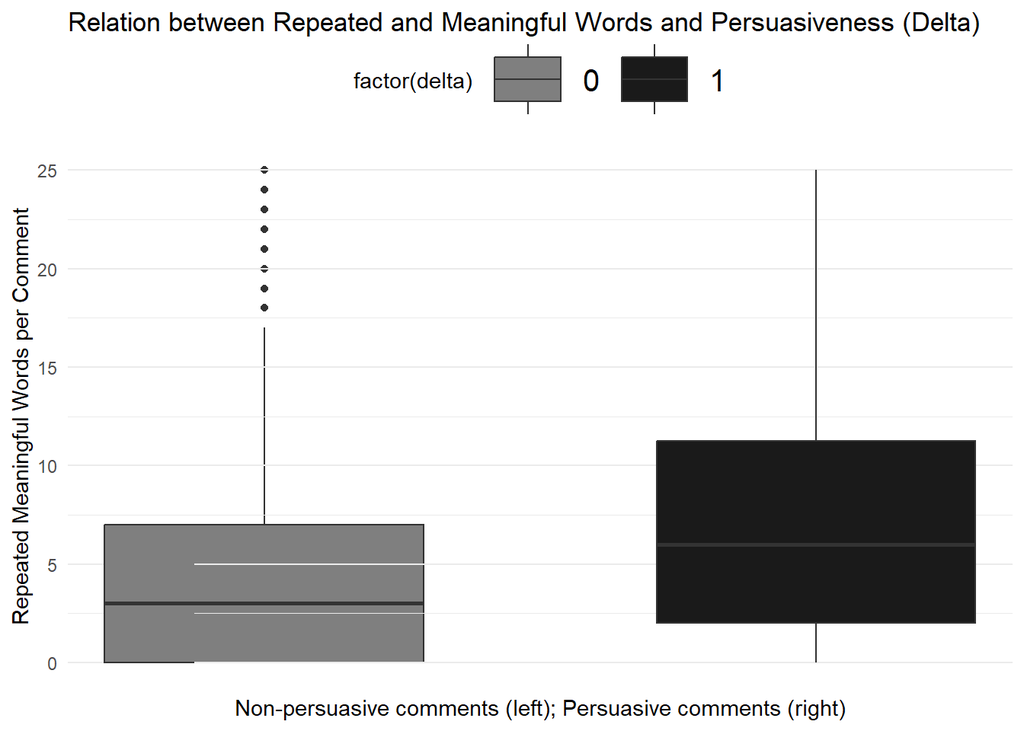

```r
# Create a boxplot of number of non-stopwords repetitions by delta value
ggplot(repetitions_df, aes(x = delta, y = counter, fill = factor(delta))) +
  geom_boxplot() +
  scale_fill_manual(values = c("gray50", "gray10")) +
  facet_wrap(~ delta, ncol = 2) +
  ylim(0, 25) +
  labs(title = "Relation between Repeated and Meaningful Words and Persuasiveness (Delta)",
       x = "Non-persuasive comments (left); Persuasive comments (right)",
       y = "Repeated Meaningful Words per Comment") +
  theme_minimal() +
  theme(panel.spacing = unit(-12, "cm"),
        legend.position = "top",
        legend.margin = margin(-0.2, 0, 0, 0, "cm"),
        axis.text.x = element_blank(),
        axis.line.x.top = element_blank(),
        panel.grid.major.x = element_blank(),
        panel.grid.minor.x = element_blank(),
        strip.text.x = element_blank(),
        legend.text = element_text(size = 15),
        legend.key.size = unit(3, "lines"))
```

**Comment’s Score**

```r
# Calculate comment_score summary statistics by delta value
comment_score_by_delta <- r %>%
  group_by(delta) %>%
  summarize(min = min(comment_score),
            max = max(comment_score),
            median = median(comment_score),
            mean = mean(comment_score),
            q25 = quantile(comment_score, 0.25),
            q75 = quantile(comment_score, 0.75),
            sd = sd(comment_score))
round(comment_score_by_delta, 0)
```

```
## # A tibble: 2 × 8
##   delta   min   max median  mean   q25   q75    sd
##   <dbl> <dbl> <dbl>  <dbl> <dbl> <dbl> <dbl> <dbl>
## 1     0   -13   716      1     6     1     3    34
## 2     1    -3  1656      3    25     1     9   130
```

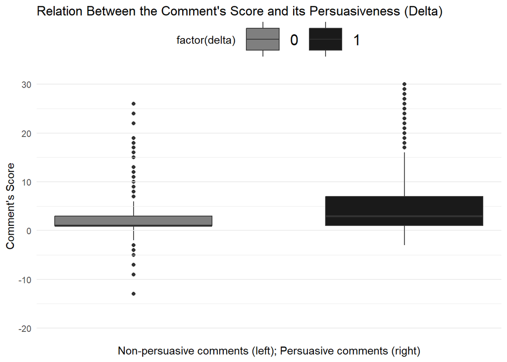

```r
# Create a boxplot of comment score by delta value
ggplot(r, aes(x = delta, y = comment_score, fill = factor(delta))) +
  geom_boxplot() +
  scale_fill_manual(values = c("gray50", "gray10")) +
  facet_wrap(~ delta, ncol = 2) +
  ylim(-20, 30) +
  labs(title = "Relation Between the Comment's Score and its Persuasiveness (Delta)",
       x = "Non-persuasive comments (left); Persuasive comments (right)",
       y = "Comment's Score") +
  theme_minimal() +
  theme(panel.spacing = unit(-12, "cm"),
        legend.position = "top",
        legend.margin = margin(-0.2, 0, 0, 0, "cm"),
        axis.text.x = element_blank(),
        axis.line.x.top = element_blank(),
        panel.grid.major.x = element_blank(),
        panel.grid.minor.x = element_blank(),
        strip.text.x = element_blank(),
        legend.text = element_text(size = 15),
        legend.key.size = unit(3, "lines"))
```

**Comment’s Type**

```r
# Create a dummy variable to distinguish between first comments and replies
r$replies <- ifelse(grepl("_", r$structure), 1, 0)
# Create table
replies_delta_table <- table(r$replies, r$delta)
# Convert table to data frame
replies_delta_df <- as.data.frame.table(replies_delta_table)
names(replies_delta_df) <- c("Replies", "Delta", "Count")
# Print dataframe
replies_delta_df
```

```
##   Replies Delta Count
## 1       0     0   248
## 2       1     0   460
## 3       0     1   374
## 4       1     1   371
```

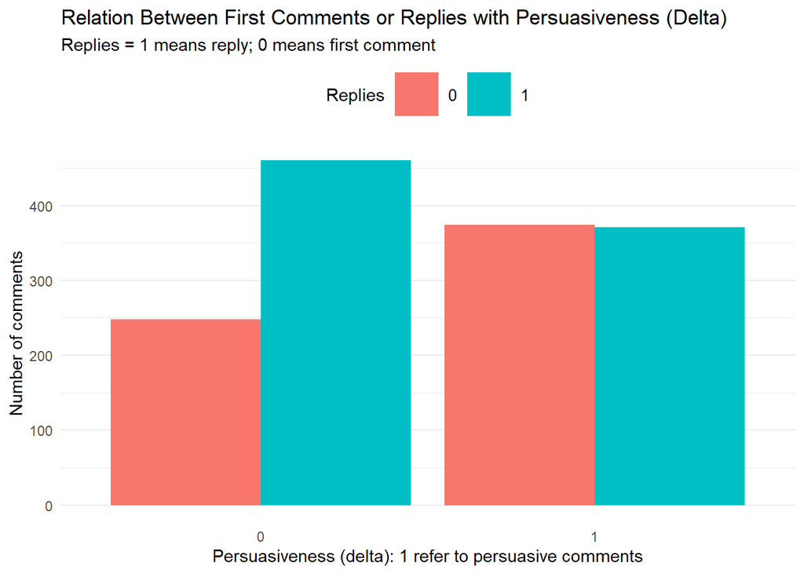

```r
# Create column plot
ggplot(replies_delta_df, aes(x = Delta, y = Count, fill = factor(Replies))) +
  geom_col(position = "dodge") +
  labs(title = "Relation Between First Comments or Replies with Persuasiveness (Delta)",
       subtitle = "Replies = 1 means reply; 0 means first comment",
       x = "Persuasiveness (delta): 1 refer to persuasive comments",
       y = "Number of comments",
       fill = "Replies") +
  theme_minimal() +
  theme(panel.spacing = unit(-12, "cm"),
        legend.position = "top",
        panel.grid.major.x = element_blank(),
        panel.grid.minor.x = element_blank(),
        strip.text.x = element_blank(),
        legend.text = element_text(size = 10),
        legend.key.size = unit(2, "lines"))
```

**Other lingustic features related with persuasiveness**

1. **Question marks:***One linguistic feature that is common in persuasive arguments is using rhetorical questions. Moreover, in the context of this data, that analyzes comments and replies to comments that try to change the point of view of the original poster, the number of questions written per comment may be an interesting feature. The code provided below counts the number of times a sentence includes at least one question mark. Thus, it counts all question type sentences per comments. According to the results, questions are more common in persuasive comments, and there are 644 question-type sentences in all the persuasive comments in the data. In contrast, there are a totsal of 488 question-type sentences in the non-persuasive comments. As the dataset in terms of delta (persuasiveness) is balanced (745 persuasive comments; 708 non-persuasive comments), the absolute comparison is adequate. However, we can also observe the mean: the average question-type sentences in persuasive comments is 0.86; for non-persuasive comments it drops to 0.69.*
2. **Repetition:***Similarly, repeating words is another common technique in persuasive rhetoric. The code above considers the number of repeated relevant words in each comment, and then it groups comments its persuasiveness (delta). Tokens are lowercased, contain no common english (“stopwords” such as ‘the’, ‘and’, ‘or’), and do not contain numbers, symbols, and punctuations marks. As it turns out, the use of relevant repeated words is a very important linguistic feature to distinguish between persuasive and non-persuasive comments. Persuasive comments (delta = 1) had 12.8 non-stop repeated words used on average (with a median of 8), while non-persuasive comments (delta = 0) had 6.8 non-stop repeated words used on average (with a median of 3). There were more almost twice (1.96) the number of relevant repeated words in persuasive comments, with 9,525 relevant repetitions in persuasive comments in total, compared with the 4,839 observed in non-persuasive comments. The rest of the descriptive stats and the boxplot printed above show how important this feature is. Of course, this feature is correlated with the length of the comments, which are larger for persuasive comments, on average. However, the average length of persuasive comments is nowhere near twice the size of non-persuasive comments, so this feature is still significant. The upper limit of the y-values of the plot is limited at 25 for a better visualization.*

### 2. Does the sentiment of a comment affect its persuasiveness? What about its appeal to moral values?

To answer these questions I will use the sentiment dictionaries included in the `quanteda.dictionaries` package, as well as the Moral Foundations Dictionary (`data_dictionary_MFD`)

```r
# Normalize the dfm by token length
comments_weighted_dfm <- dfm(comments_tokens) %>%
  dfm_weight(scheme="prop")
# Normalize the clean dfm by token length
comments_clean_weighted_dfm <- dfm_weight(comments_clean_dfm, scheme="prop")
```

```r
# Create character lists for positive and negative words
pos_words_1 <- data_dictionary_geninqposneg[["positive"]]
neg_words_1 <- data_dictionary_geninqposneg[["negative"]]
sentiment_dict_1 <- dictionary(list(positive = pos_words_1, negative = neg_words_1))
# Apply dictionary using `dfm_lookup()` function:
comments_sentiment_1 <- dfm_lookup(comments_weighted_dfm, dictionary = sentiment_dict_1)
comments_clean_sentiment_1 <- dfm_lookup(comments_clean_weighted_dfm, dictionary = sentiment_dict_1)
# Convert dfm into a dictionary
comments_sentiment_df <- cbind(convert(comments_sentiment_1, to = "data.frame"),
                               delta = r$delta) %>%
  drop_na() %>%
  mutate(sentiment_score = positive - negative) %>%
  select(doc_id, delta, positive, negative, sentiment_score)
# Convert clean dfm into a dictionary
comments_clean_sentiment_df <- cbind(convert(comments_clean_sentiment_1, to = "data.frame"),
                               delta = r$delta) %>%
  drop_na() %>%
  mutate(sentiment_score = positive - negative) %>%
  select(doc_id, delta, positive, negative, sentiment_score)
# Build a sentiment analysis table grouped by delta
comments_sentiment_df$sentiment[comments_sentiment_df$sentiment_score==0] <- "neutral"
comments_sentiment_df$sentiment[comments_sentiment_df$sentiment_score<0] <- "negative"
comments_sentiment_df$sentiment[comments_sentiment_df$sentiment_score>0] <- "positive"
sentiment_table_geninqposneg <- table(comments_sentiment_df$sentiment, comments_sentiment_df$delta)
# Build a sentiment analysis table grouped by delta for the clean dfm
comments_clean_sentiment_df$sentiment[comments_clean_sentiment_df$sentiment_score==0] <- "neutral"
comments_clean_sentiment_df$sentiment[comments_clean_sentiment_df$sentiment_score<0] <- "negative"
comments_clean_sentiment_df$sentiment[comments_clean_sentiment_df$sentiment_score>0] <- "positive"
sentiment_table_clean_geninqposneg <- table(comments_clean_sentiment_df$sentiment, comments_clean_sentiment_df$delta)
```

```r
pos_words_2 <- data_dictionary_HuLiu[["positive"]]
neg_words_2 <- data_dictionary_HuLiu[["negative"]]
sentiment_dict_2 <- dictionary(list(positive = pos_words_2, negative = neg_words_2))
# Apply dictionary using `dfm_lookup()` function:
comments_sentiment_2 <- dfm_lookup(comments_weighted_dfm, dictionary = sentiment_dict_2)
comments_clean_sentiment_2 <- dfm_lookup(comments_clean_weighted_dfm, dictionary = sentiment_dict_2)
# Convert dfm into a dictionary
comments_sentiment_df <- cbind(convert(comments_sentiment_2, to = "data.frame"),
                               delta = r$delta) %>%
  drop_na() %>%
  mutate(sentiment_score = positive - negative) %>%
  select(doc_id, delta, positive, negative, sentiment_score)
# Convert clean dfm into a dictionary
comments_clean_sentiment_df <- cbind(convert(comments_clean_sentiment_2, to = "data.frame"),
                               delta = r$delta) %>%
  drop_na() %>%
  mutate(sentiment_score = positive - negative) %>%
  select(doc_id, delta, positive, negative, sentiment_score)
# Build a sentiment analysis table grouped by delta
comments_sentiment_df$sentiment[comments_sentiment_df$sentiment_score==0] <- "neutral"
comments_sentiment_df$sentiment[comments_sentiment_df$sentiment_score<0] <- "negative"
comments_sentiment_df$sentiment[comments_sentiment_df$sentiment_score>0] <- "positive"
sentiment_table_HuLiu <- table(comments_sentiment_df$sentiment, comments_sentiment_df$delta)
# Build a sentiment analysis table grouped by delta for the clean dfm
comments_clean_sentiment_df$sentiment[comments_clean_sentiment_df$sentiment_score==0] <- "neutral"
comments_clean_sentiment_df$sentiment[comments_clean_sentiment_df$sentiment_score<0] <- "negative"
comments_clean_sentiment_df$sentiment[comments_clean_sentiment_df$sentiment_score>0] <- "positive"
sentiment_table_clean_HuLiu <- table(comments_clean_sentiment_df$sentiment, comments_clean_sentiment_df$delta)
```

```r
pos_words_3 <- data_dictionary_NRC[["positive"]]
neg_words_3 <- data_dictionary_NRC[["negative"]]
sentiment_dict_3 <- dictionary(list(positive = pos_words_3, negative = neg_words_3))
# Apply dictionary using `dfm_lookup()` function:
comments_sentiment_3 <- dfm_lookup(comments_weighted_dfm, dictionary = sentiment_dict_3)
comments_clean_sentiment_3 <- dfm_lookup(comments_clean_weighted_dfm, dictionary = sentiment_dict_3)
# Convert dfm into a dictionary
comments_sentiment_df <- cbind(convert(comments_sentiment_3, to = "data.frame"),
                               delta = r$delta) %>%
  drop_na() %>%
  mutate(sentiment_score = positive - negative) %>%
  select(doc_id, delta, positive, negative, sentiment_score)
# Convert clean dfm into a dictionary
comments_clean_sentiment_df <- cbind(convert(comments_clean_sentiment_3, to = "data.frame"),
                               delta = r$delta) %>%
  drop_na() %>%
  mutate(sentiment_score = positive - negative) %>%
  select(doc_id, delta, positive, negative, sentiment_score)
# Build a sentiment analysis table grouped by delta
comments_sentiment_df$sentiment[comments_sentiment_df$sentiment_score==0] <- "neutral"
comments_sentiment_df$sentiment[comments_sentiment_df$sentiment_score<0] <- "negative"
comments_sentiment_df$sentiment[comments_sentiment_df$sentiment_score>0] <- "positive"
sentiment_table_NRC <- table(comments_sentiment_df$sentiment, comments_sentiment_df$delta)
# Build a sentiment analysis table grouped by delta for the clean dfm
comments_clean_sentiment_df$sentiment[comments_clean_sentiment_df$sentiment_score==0] <- "neutral"
comments_clean_sentiment_df$sentiment[comments_clean_sentiment_df$sentiment_score<0] <- "negative"
comments_clean_sentiment_df$sentiment[comments_clean_sentiment_df$sentiment_score>0] <- "positive"
sentiment_table_clean_NRC <- table(comments_clean_sentiment_df$sentiment, comments_clean_sentiment_df$delta)
```

```r
# Print tables
sentiment_table_clean_geninqposneg
```

```
##
##              0   1
##   negative 147 144
##   neutral   82  82
##   positive 479 519
```

```r
sentiment_table_clean_HuLiu
```

```
##
##              0   1
##   negative 278 291
##   neutral  128  97
##   positive 302 357
```

```r
sentiment_table_clean_NRC
```

```
##
##              0   1
##   negative 194 206
##   neutral  120  66
##   positive 394 473
```

```r
# Calculate positive ratio for delta = 0
pos_ratio_geninq_0 <- sum(sentiment_table_clean_geninqposneg["positive", "0"]) / sum(sentiment_table_clean_geninqposneg[c("positive", "negative", "neutral"), "0"])
# Calculate positive ratio for delta = 1
pos_ratio_geninq_1 <- sum(sentiment_table_clean_geninqposneg["positive", "1"]) / sum(sentiment_table_clean_geninqposneg[c("positive", "negative", "neutral"), "1"])
# Calculate positive ratio for delta = 0
pos_ratio_HuLiu_0 <- sum(sentiment_table_clean_HuLiu["positive", "0"]) / sum(sentiment_table_clean_HuLiu[c("positive", "negative", "neutral"), "0"])
# Calculate positive ratio for delta = 1
pos_ratio_HuLiu_1 <- sum(sentiment_table_clean_HuLiu["positive", "1"]) / sum(sentiment_table_clean_HuLiu[c("positive", "negative", "neutral"), "1"])
# Calculate positive ratio for delta = 0
pos_ratio_NRC_0 <- sum(sentiment_table_clean_NRC["positive", "0"]) / sum(sentiment_table_clean_NRC[c("positive", "negative", "neutral"), "0"])
# Calculate positive ratio for delta = 1
pos_ratio_NRC_1 <- sum(sentiment_table_clean_NRC["positive", "1"]) / sum(sentiment_table_clean_NRC[c("positive", "negative", "neutral"), "1"])
pos_ratio_geninq_1 - pos_ratio_geninq_0
```

```
## [1] 0.02009062
```

```r
pos_ratio_HuLiu_1 - pos_ratio_HuLiu_0
```

```
## [1] 0.05264096
```

```r
pos_ratio_NRC_1 - pos_ratio_NRC_0
```

```
## [1] 0.07840215
```

```r
# Load the dictionary
data("data_dictionary_MFD")
moral <- dfm_lookup(comments_clean_weighted_dfm, dictionary = data_dictionary_MFD)
moral_sentiment_df <- cbind(convert(moral, to = "data.frame"),
                               delta = r$delta) %>%
  mutate(virtue_score = care.virtue + fairness.virtue + loyalty.virtue + authority.virtue + sanctity.virtue -
           care.vice - fairness.vice - loyalty.vice - authority.vice - sanctity.vice)
# Calculate moral sentiment summary statistics by delta value
moral_sentiment_by_delta <- moral_sentiment_df %>%
  group_by(delta) %>%
  summarize(min = min(virtue_score),
            max = max(virtue_score),
            median = median(virtue_score),
            mean = mean(virtue_score),
            q25 = quantile(virtue_score, 0.25),
            q75 = quantile(virtue_score, 0.75),
            sd = sd(virtue_score))
round(moral_sentiment_by_delta, 2)
```

```
## # A tibble: 2 × 8
##   delta   min   max median  mean   q25   q75    sd
##   <dbl> <dbl> <dbl>  <dbl> <dbl> <dbl> <dbl> <dbl>
## 1     0 -0.4    0.4   0     0.02     0  0.04  0.06
## 2     1 -0.33   0.2   0.01  0.02     0  0.04  0.05
```

```r
moral_sentiment_df$morality[moral_sentiment_df$virtue_score==0] <- "neutral"
moral_sentiment_df$morality[moral_sentiment_df$virtue_score<0] <- "vicious"
moral_sentiment_df$morality[moral_sentiment_df$virtue_score>0] <- "virtuous"
moral_table <- table(moral_sentiment_df$morality, moral_sentiment_df$delta)
moral_table
```

```
##
##              0   1
##   neutral  287 239
##   vicious  123 114
##   virtuous 298 392
```

**Sentiment Analysis**

### 3. Are off-topic comments less likely to be convincing?

To answer this question, compute a metric of distance between `post_text` – the text of the original post (from the author who wants to be convinced) – and `comment` – the text of the comment that was found persuasive. Do this for each row of the dataset. Use any metric that you find appropriate, paying attention as usual to whether any type of normalization is required. Explain why this metric may capture whether a comment is `off-topic` or not.

```r
# create separate data frames for comment and post_text
comment_r <- r %>%
  select(title, comment, delta) %>%
  rename(text = comment) %>%
  mutate(is_comment = TRUE)
post_text_r <- r %>%
  select(title, post_text, delta) %>%
  rename(text = post_text) %>%
  mutate(is_comment = FALSE)
# row bind the two data frames
longer_r <- bind_rows(comment_r, post_text_r) %>%
  arrange(title, is_comment) # arrange by title and is_comment columns
# remove duplicates based on title and text columns
longer_r <- distinct(longer_r, title, text, .keep_all = TRUE)
# create an id
longer_r <- longer_r %>%
  group_by(title) %>%
  mutate(title_id = cur_group_id())
# Add document variables to dfm
off_topic_dfm <- longer_r$text %>%
  corpus(docvars = data.frame(title = longer_r$title_id,
                              is_comment = longer_r$is_comment,
                              delta = longer_r$delta)) %>%
  tokens(remove_punct = TRUE, remove_numbers = TRUE,
         remove_symbols = TRUE, remove_url = TRUE) %>%
  tokens_remove(stopwords("en")) %>%
  tokens_wordstem() %>%
  dfm()
```

```r
# Calculate cosine similarities
cosine_mat <- as.matrix(textstat_simil(off_topic_dfm, method = "cosine", margin = "documents"))
cosine_df <- as.data.frame(cosine_mat)
# Get document names
docnames <- rownames(cosine_df)
# Create data frame with document names, titles, and is_comment variables
docinfo <- data.frame(docname = docnames,
                      title_id = longer_r$title_id,
                      is_comment = longer_r$is_comment,
                      delta = longer_r$delta)
# Create matcher variable
matcher <- docinfo %>%
  filter(!is_comment) %>%
  group_by(title_id) %>%
  slice(1) %>%
  mutate(matcher = docname) %>%
  select(title_id, matcher)
# Join data frames
cosine_df <- cbind(docinfo, cosine_df)
# Join with matcher
cosine_df <- cosine_df %>%
  left_join(matcher, by = "title_id")
# Add cosine column
cosine_df$cosine <- apply(cosine_df, 1, function(x) {
  colname <- x["matcher"]
  if (colname %in% colnames(cosine_df)) {
    x[colname]
  } else {
    NA
  }
})
```

```r
# Filter df
cosine_df <- cosine_df %>%
  filter(is_comment == TRUE) %>%
  mutate(cosine = as.numeric(cosine)) %>%
  drop_na(cosine) %>%
  select(docname, title_id, cosine, delta)
# Calculate summary statistics by delta value
cosine_by_delta <- cosine_df %>%
  group_by(delta) %>%
  summarize(min = min(cosine),
            max = max(cosine),
            median = median(cosine),
            mean = mean(cosine),
            q25 = quantile(cosine, 0.25),
            q75 = quantile(cosine, 0.75),
            sd = sd(cosine))
cosine_by_delta
```

```
## # A tibble: 2 × 8
##   delta   min   max median  mean   q25   q75    sd
##   <int> <dbl> <dbl>  <dbl> <dbl> <dbl> <dbl> <dbl>
## 1     0     0 0.725  0.194 0.210 0.116 0.291 0.131
## 2     1     0 0.757  0.238 0.249 0.149 0.332 0.139
```

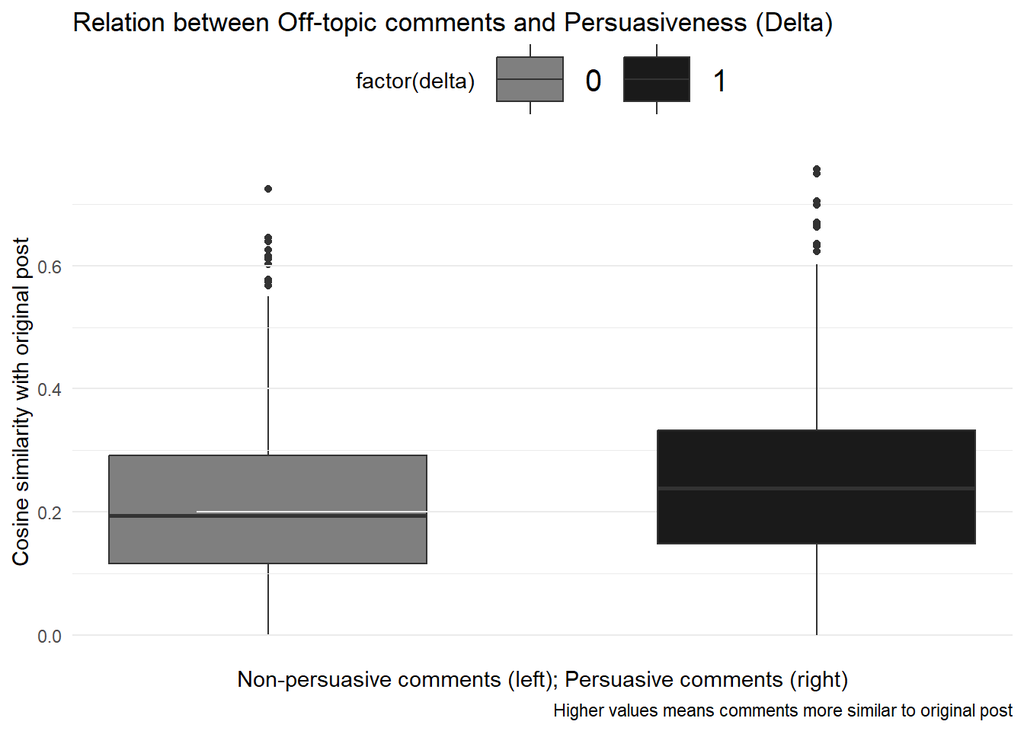

```r
# Create a boxplot of number of non-stopwords repetitions by delta value
ggplot(cosine_df, aes(x = delta, y = cosine, fill = factor(delta))) +
  geom_boxplot() +
  scale_fill_manual(values = c("gray50", "gray10")) +
  facet_wrap(~ delta, ncol = 2) +
  labs(title = "Relation between Off-topic comments and Persuasiveness (Delta)",
       x = "Non-persuasive comments (left); Persuasive comments (right)",
       y = "Cosine similarity with original post",
       caption = "Higher values means comments more similar to original post") +
  theme_minimal() +
  theme(panel.spacing = unit(-12, "cm"),
        legend.position = "top",
        legend.margin = margin(-0.2, 0, 0, 0, "cm"),
        axis.text.x = element_blank(),
        axis.line.x.top = element_blank(),
        panel.grid.major.x = element_blank(),
        panel.grid.minor.x = element_blank(),
        strip.text.x = element_blank(),
        legend.text = element_text(size = 15),
        legend.key.size = unit(3, "lines"))
```

**Your answer here.** *For this exercise we will use cosine similarity, that can be applied using the textstat_simil() function from quanteda. Cosine similarity is a good metric for this exercise because it is unaffected by document length, as it focuses on the angle between two vectors, rather than just their magnitudes (length). In other words, cosine similarity measures the similarity between two text documents by comparing the frequency of words in the two documents. Each document is represented as a vector of word frequencies, and the cosine similarity between the two vectors is calculated as the cosine of the angle between them.* *According to the results, non-persuasive comments are slightly more off-topic than persuasive comments, as the mean and median value of the cosine similarity between non-persuasive comments and its correspondent original post they reply to is 0.21 (mean) and 0.19 (median); for persuasive comments (delta = 1) the mean and median values are 0.25 and 0.24, respectively. By using the mean values, we can establish that persuasive comments are 3.8 percentage points more similar to the original post in terms of the topic by 3.8 percentage points than non-persuasive comments.*

### 4. What words appear to be good predictors of persuasion?

Are there specific words that are predictive that a thread or comment will lead to persuasion? Or maybe some specific issues about which more people are likely to change their view? To answer this question, we will use keyness analysis to detect which words are more likely to appear in comments that persuade people (`comment` variable) and in the text of the post (`post_text`) that started the conversation.

```r
# Analysis between persuasive and non persuasive comments
docvars(comments_clean_dfm, "delta") <- r$delta
delta_dfm <- comments_clean_dfm %>%
  dfm_group(groups = delta)
(head(delta <- textstat_keyness(delta_dfm), 20))
```

```
##       feature     chi2            p n_target n_reference
## 1   character 26.88039 2.164435e-07       33          12
## 2  hypnotized 21.20462 4.127685e-06       14           1
## 3   christian 19.19016 1.183217e-05       19           5
## 4  confidence 18.96737 1.329734e-05       16           3
## 5      racist 18.43216 1.760612e-05       27          12
## 6        game 17.93938 2.280532e-05       34          19
## 7     fucking 17.62320 2.692829e-05       18           5
## 8     portion 17.62320 2.692829e-05       18           5
## 9       black 16.79405 4.166365e-05       65          55
## 10    emotion 16.54487 4.751242e-05       13           2
## 11       race 15.74409 7.251417e-05       36          23
## 12       just 15.43641 8.532816e-05      342         456
## 13    perfect 15.31438 9.102086e-05       19           7
## 14   pronouns 14.97247 1.090911e-04       10           0
## 15     french 14.86443 1.155211e-04       12           2
## 16  insulting 14.86443 1.155211e-04       12           2
## 17       role 14.54541 1.368213e-04       16           5
## 18     decade 13.67622 2.171878e-04       11           1
## 19       jobs 13.66710 2.182452e-04       35          24
## 20  electoral 13.65484 2.196745e-04       19           8
```

```r
(tail(delta <- textstat_keyness(delta_dfm), 20))
```

```
##           feature       chi2            p n_target n_reference
## 14416  experience  -9.444793 2.117494e-03       20          75
## 14417         cis  -9.546121 2.003724e-03        1          21
## 14418      robots  -9.646773 1.896845e-03        0          17
## 14419     extreme  -9.730855 1.812002e-03        5          35
## 14420       power  -9.859907 1.689197e-03       24          86
## 14421        mars -10.105143 1.478561e-03        1          22
## 14422   happiness -10.232504 1.379872e-03        5          36
## 14423     million -10.329625 1.309118e-03        4          33
## 14424       water -10.697118 1.073026e-03        8          46
## 14425       trans -11.030901 8.960560e-04       18          74
## 14426    children -11.145938 8.421587e-04       23          87
## 14427       delta -12.267246 4.609781e-04       11          58
## 14428    calories -13.471893 2.421638e-04        1          28
## 14429   privilege -13.471893 2.421638e-04        1          28
## 14430      mental -14.126575 1.709121e-04        7          50
## 14431  inequality -15.160892 9.872713e-05        1          31
## 14432     suicide -15.238811 9.473634e-05        6          49
## 14433 advertising -16.852388 4.040247e-05        1          34
## 14434     poverty -16.852388 4.040247e-05        1          34
## 14435        term -27.922678 1.262612e-07       12          93
```

```r
r_by_title <- r %>%
  group_by(title) %>%
  mutate(has_persuasive = ifelse(any(delta == 1), 1, 0)) %>%
  ungroup() %>%
  select(title, post_text, has_persuasive) %>%
  distinct(title, post_text, has_persuasive)
# Create a corpus
posts_corpus <- corpus(r_by_title$post_text)
# Create a clean tokenized corpus
posts_corpus_toks <- tokens(posts_corpus,
                                remove_punct = T,
                                remove_symbols = T,
                                remove_numbers = T,
                                remove_url = T)
# Remove stopwords for a better analysis of lexical diversity (as in lab-session 1)
posts_corpus_toks <- tokens_remove(posts_corpus_toks, stopwords("english"))
# Create a clean dfm from the clean tokenized corpus, nowwithout stopwords as well
posts_corpus_dfm <- dfm(posts_corpus_toks)
# Analysis between persuasive and non persuasive comments
docvars(posts_corpus_dfm, "has_persuasive") <- r_by_title$has_persuasive
delta_posts_dfm <- posts_corpus_dfm %>%
  dfm_group(groups = has_persuasive)
(head(delta <- textstat_keyness(delta_posts_dfm), 20))
```

```
##        feature     chi2            p n_target n_reference
## 1        malum 29.73680 4.948632e-08       19           0
## 2        music 29.05102 7.049688e-08       34           9
## 3       mobile 28.00327 1.211107e-07       22           2
## 4         trap 26.38183 2.801634e-07       19           1
## 5           hb 25.04082 5.612944e-07       16           0
## 6   prohibitum 23.47555 1.265116e-06       15           0
## 7         cars 23.40722 1.310855e-06       19           2
## 8           gt 22.91374 1.694364e-06      101          78
## 9          feb 21.91030 2.856956e-06       14           0
## 10  confidence 20.36090 6.412689e-06       17           2
## 11  punishment 19.08389 1.250962e-05       21           5
## 12   emissions 16.30240 5.399565e-05       12           0
## 13       kanye 16.30240 5.399565e-05       12           0
## 14     minimum 14.99970 1.075281e-04       27          12
## 15 antisemitic 14.74523 1.230586e-04       11           0
## 16         awb 14.74523 1.230586e-04       11           0
## 17        gaze 14.74523 1.230586e-04       11           0
## 18 orientation 14.33603 1.529103e-04       13           2
## 19   christian 14.14354 1.693774e-04       16           4
## 20       girls 14.14354 1.693774e-04       16           4
```

```r
(tail(delta <- textstat_keyness(delta_posts_dfm), 20))
```

```
##            feature       chi2            p n_target n_reference
## 14013    holocaust  -9.587132 1.959458e-03        0          15
## 14014 translations  -9.587132 1.959458e-03        0          15
## 14015     campaign  -9.714955 1.827746e-03        1          19
## 14016   conspiracy  -9.714955 1.827746e-03        1          19
## 14017         deny  -9.714955 1.827746e-03        1          19
## 14018      literal  -9.714955 1.827746e-03        1          19
## 14019       robots -10.226370 1.384469e-03        0          16
## 14020      someone -10.433612 1.237425e-03       76         184
## 14021      product -10.597025 1.132698e-03        4          30
## 14022        house -10.601394 1.130024e-03        3          27
## 14023         team -10.601394 1.130024e-03        3          27
## 14024   acceptable -10.708507 1.066440e-03        2          24
## 14025      esports -10.865619 9.796598e-04        0          17
## 14026   philosophy -10.865619 9.796598e-04        0          17
## 14027         term -11.346752 7.558003e-04       18          67
## 14028      content -11.765817 6.032840e-04        4          32
## 14029     morality -13.540230 2.335038e-04        4          35
## 14030        human -18.400100 1.790486e-05       23          94
## 14031         life -18.708081 1.523355e-05       59         175
## 14032         soap -19.816372 8.524934e-06        0          31
```

**Your answer here.**

**Keyness analysis** *The first thing for this analysis is to group the documents form the cleaned dfm in persuasive and non-persuasive comments. Afterwards, textstat_keyness() is used, and the target is the document that bind all persuasive comments together. Hence, the first twenty entries (head(…) show the words (features) that are significantly more frequent among the persuasive comments in contrast with non-persuasive comments, whereas the last twenty entries (tail()) show the opposite. For the analysis of posts we start by creating a dfm for where post_text are the documents. Then we group the post text into two categories: posts in which at least one persuasive comment was included, other posts. Of the 633 unique posts, 381 (60.2%) have at least one persuasive comment, while 252 (39.8%) does not have any persuasive comment in the post’s thread. A similar analysis of printing the first (head()) and last (tail()) features in terms of keyness is performed, albeit the grouping variable is if the post has any persuasive comment in the thread or not.*

1. **Comments:**

1.1. **Frequent features in persuasive comments:***Very interesting features appear in the top 20, such as: christian, racist, race, black, and electoral. This features can be grouped in three categories: religion, racism, and democracy/voting discussions. By analyzing the keyness of the comments, it seems these topics, especially racism because of the number of features that appear in the top 20, are more prone to be included in persuasive comments.*

1.2. **Infrequent features in persuasive comments:***In contrast, grouped features that appear in the bottom 20 that are worthy of highlighting are: 1. robots, water, and mars; 2. power, million, poverty, inequality, and privilege; 3. mental, happiness, and suicide; and 4. trans. This four features can be thought as four different topics, all of which seem to be very difficult to lead to persuasion: 1. the future; 2. criticism to capitalism; 3. mental health; and 4. trans rights.*

2. **Posts:**

2.1. **Frequent features in posts with at least one persuasive comment:***Topics such as the recent antisemitism that started with Kanye (“antisemitism”, “kanye”); and about cars and its damage to the environment (“cars”, “emissions”) seem to be post topics that are more likely to include persuasive comments.*

2.2. **Frequent features in posts with no persuasive comments:***In contrast, posts with arguments about the key questions of human life (with features such as “life”, “morality”, “philosophy”, and “human”), robots, and conspiracy theories (“holocaust”, “deny”, “campaign”, “conspiracy”) are seemingly less likely to include persuasive comments.*

### 5. Is persuasion more likely to happen for some topics than others?

Are specific topics about which people are more likely to change their mind? To answer this question, we will fit a topic model with the text of the original post (`post_text`). We will also choose a number of topics that seems appropriate. Then, we will add a new variable to the data frame that refers to the most likely topic for that post. Finally, we will compute the proportion of threads related to that topic for which a delta was assigned.

```r
posts_corpus_toks_clean <- tokens_remove(posts_corpus_toks,
                                         c("also", "s", "t", "m", "get", "go", "can", "ubi", "cmv",
                                           "downvotes", "amp", "#x200b", "one", "said", "say",
                                           "comment", "views", "firstly", "gt", "etc", "don", "use",
                                           "however", "think", "saying"))
posts_corpus_dfm_clean <- dfm(posts_corpus_toks_clean)
posts_corpus_dfm_trim <- dfm(posts_corpus_dfm_clean) %>%
  dfm_trim(min_docfreq = 2)
# estimate LDA with K topics
K <- 4
# We throw away the first 100 iterations with the burnin, and the we resample 500 for the model
lda <- LDA(posts_corpus_dfm_trim, k = K, method = "Gibbs",
                control = list(verbose=25L, seed = 123, burnin = 100, iter = 500))
```

```
## K = 4; V = 6605; M = 633
## Sampling 600 iterations!
## Iteration 25 ...
## Iteration 50 ...
## Iteration 75 ...
## Iteration 100 ...
## Iteration 125 ...
## Iteration 150 ...
## Iteration 175 ...
## Iteration 200 ...
## Iteration 225 ...
## Iteration 250 ...
## Iteration 275 ...
## Iteration 300 ...
## Iteration 325 ...
## Iteration 350 ...
## Iteration 375 ...
## Iteration 400 ...
## Iteration 425 ...
## Iteration 450 ...
## Iteration 475 ...
## Iteration 500 ...
## Iteration 525 ...
## Iteration 550 ...
## Iteration 575 ...
## Iteration 600 ...
## Gibbs sampling completed!
```

```r
r_by_title <- r %>%
  group_by(title) %>%
  mutate(has_persuasive = ifelse(any(delta == 1), 1, 0)) %>%
  ungroup() %>%
  select(title, post_text, has_persuasive) %>%
  distinct(title, post_text, has_persuasive)

topics <- get_topics(lda, 1) %>%
  as.data.frame() %>%
  rename(main_topic = ".") %>%
  rownames_to_column("id")
r_by_title <- cbind(topics, r_by_title)

# Count main topics for has_persuasive = 1
freq_has_persuasive_1 <- r_by_title %>%
  filter(has_persuasive == 1) %>%
  count(main_topic, sort = TRUE) %>%
  mutate(share = round(n/sum(n),2)) %>%
  rename(occurrences = n)
# Count main topics for has_persuasive = 0
freq_has_persuasive_0 <- r_by_title %>%
  filter(has_persuasive == 0) %>%
  count(main_topic, sort = TRUE) %>%
  mutate(share = round(n/sum(n),2)) %>%
  rename(occurrences = n)

topics_persuasive <- inner_join(freq_has_persuasive_1,
                                freq_has_persuasive_0,
                                by = "main_topic",
                                suffix = c("_pers", "_non-pers"))
topics_persuasive
```

```
##   main_topic occurrences_pers share_pers occurrences_non-pers share_non-pers
## 1          2              113       0.30                   64           0.25
## 2          1               92       0.24                   80           0.32
## 3          4               92       0.24                   57           0.23
## 4          3               84       0.22                   51           0.20
```

```r
# Select main topics and get the first 20 terms for each topic
maintopics <- get_topics(lda, 1)
terms <- get_terms(lda, 20)
# Topic 1
# Take the vector of terms of topic 1
paste(terms[,1], collapse=", ")
```

```
## [1] "us, people, change, free, things, see, like, work, please, money, read, happy, feel, rules, questions, couple, effective, speaking, concerns, system"
```

```r
# Random sample of topics assigned to topic number 1
sample(r_by_title$post_text[maintopics==1], 1)
```

```
## [1] "I've seen people talk about CaaS as if it's an inevitability which will completely kill car ownership but I don't understand at all how that could work. I've tried to do a little reading about it but haven't seen any real talk about the logistics of it. To be clear, I understand how car shar…
```

```r
# CODE FOR SIMILAR ANALYSIS FOR THE OTHER THREE TOPICS
# Topic 2
# Take the vector of terms of topic 2
##paste(terms[,2], collapse=", ")
# Random sample of topics assigned to topic number 2
##sample(r_by_title$post_text[maintopics==2], 1)
# Topic 3
# Take the vector of terms of topic 3
##paste(terms[,3], collapse=", ")
# Random sample of topics assigned to topic number 3
##sample(r_by_title$post_text[maintopics==3], 1)
# Topic 4
# Take the vector of terms of topic 4
##paste(terms[,4], collapse=", ")
# Random sample of topics assigned to topic number 4
##sample(r_by_title$post_text[maintopics==4], 1)
```